# Determination of Most Harmful Weather Events Across the US

Lee Mendoza

Saturday, April 25, 2015

## Synopsis

Harmful weather events are determined by analyzing National Weather Service data for weather events recorded from 1994 through 2011. Events most harmful with respect to population health (those resulting in deaths and injuries) are determined as are those having economic consequences (those resulting in property and crop damage). The top 10 most harmful events, across the US, are shown. The most harmful events for each state are also determined and shown graphically. These results may be of use to government or municipal managers who might be responsible for planning and preparing for severe weather events.

## Data Processing

```r
## All code and ancillary files are available in the github repository -
## https://github.com/leemendoza/RepData_PeerAssessment2

################################ DATA PROCESSING ###############################
## the data have already been downloaded and should be in the current directory. If not,
## uncomment the following two lines and download the data:
##setInternet2(use = TRUE)
##download.file("https://d396qusza40orc.cloudfront.net/repdata%2Fdata%2FStormData.csv.bz2", "FStormData.bz2", mode = "wb")

## it's not necessary to decompress the file, R can read it directly. See this link...
## https://entropicevolution.wordpress.com/2014/01/24/learning-r-r-can-read-compressed-files/
dt =  read.table("FStormData.bz2", header = TRUE, fill = TRUE, stringsAsFactors = FALSE, sep = ",")
```

```r
## convert dates to a useful format
dt$BGN_DATE = as.Date(dt$BGN_DATE, "%m/%d/%Y")
dt$END_DATE = as.Date(dt$END_DATE, "%m/%d/%Y")

## FILTERING ###############################
## it appears that event reporting increased substantially beginning in 1993.
## Since years before 1994 are inconsistent, events occurring before 1994 are ignored
dt = filter(dt, BGN_DATE >= "1994-01-01")

## let's also ignore events that caused no injuries, fatalities, property damage, and crop damage
harmful = filter(dt, INJURIES > 0 | FATALITIES > 0 | PROPDMG > 0 | CROPDMG > 0)

## CLASSIFICATION ##########################
## there are 449 different levels of event type in the data, many of which do not match
## the event categories in the National Weather Service Instructions 10-1605
## <https://d396qusza40orc.cloudfront.net/repdata%2Fpeer2_doc%2Fpd01016005curr.pdf>
## The reported events should be classified according to the National Weather Service (NWS)
## categories listed in the documentation. We'll start by creating a NWS column
## which indicates the new assigned NWS category
harmful$NWS = NA

## eventmap.xlsx contains a mapping of the reported events in the original data to the
## event categories in the NWS Instructions 10-1605.
## The map was manually created by determining the closest match of the reported event in the data
## to the NWS category. In cases in which the event was listed as a combination (such as
## Hurricane/High Winds) the first reported event listed was used to classify the event,
## on the assumption that the data collector listed the most significant event first.

## load the mapping file from the current folder
map = read.xlsx2("eventmap.xlsx", 1, stringsAsFactors = FALSE)

## loop through the mapping file, adding the NWS-mapped event type to the harmful data
for (i in 1:nrow(map)){
    harmful$NWS[which(harmful$EVTYPE == map$EVTYPE[i])] = map$NWS[i]
}

## make the NWS category a factor
harmful$NWS = as.factor(harmful$NWS)

## prepare the data to calculate economic consequence
## the new PropMult column will be used as a numeric factor (based on the PROPDMGEXP column)
## with which to multiply the PROPDMG amount. The default value is 1
harmful$PropMult = 1
harmful$PropMult[which(harmful$PROPDMGEXP == 'b' | harmful$PROPDMGEXP == 'B')] = 1000000000
harmful$PropMult[which(harmful$PROPDMGEXP == 'm' | harmful$PROPDMGEXP == 'M')] = 1000000
harmful$PropMult[which(harmful$PROPDMGEXP == 'k' | harmful$PROPDMGEXP == 'K')] = 1000
harmful$PropMult[which(harmful$PROPDMGEXP == 'h' | harmful$PROPDMGEXP == 'H')] = 100
harmful$PropMult[which(harmful$PROPDMGEXP == '0') ] = 1
harmful$PropMult[which(harmful$PROPDMGEXP == '2') ] = 100
harmful$PropMult[which(harmful$PROPDMGEXP == '3') ] = 1000
harmful$PropMult[which(harmful$PROPDMGEXP == '4') ] = 10000
harmful$PropMult[which(harmful$PROPDMGEXP == '5') ] = 100000
harmful$PropMult[which(harmful$PROPDMGEXP == '6') ] = 1000000
harmful$PropMult[which(harmful$PROPDMGEXP == '7') ] = 10000000

## calculate the costs
harmful$PropCost = as.numeric(harmful$PROPDMG * harmful$PropMult)

## we need a similar transformation for the crop damage calculation. The CROPDMGEXP
## column has fewer unique values than the PROPDMGEXP column
harmful$CropMult = 1
harmful$CropMult[which(harmful$CROPDMGEXP == 'b' | harmful$CROPDMGEXP == 'B')] = 1000000000
harmful$CropMult[which(harmful$CROPDMGEXP == 'm' | harmful$CROPDMGEXP == 'M')] = 1000000
harmful$CropMult[which(harmful$CROPDMGEXP == 'k' | harmful$CROPDMGEXP == 'K')] = 1000
harmful$CropMult[which(harmful$CROPDMGEXP == 'h' | harmful$CROPDMGEXP == 'H')] = 100
harmful$CropMult[which(harmful$CROPDMGEXP == '0') ] = 1

## now calculate the costs
harmful$CropCost = as.numeric(harmful$CROPDMG * harmful$CropMult)

## for discussion purposes, summarize the overall damage by event type, over all areas
damage = harmful %>%
    group_by(NWS) %>%
    summarize(Fatalities = sum(FATALITIES), Injuries = sum(INJURIES),
              Property = sum(PropCost)/1000000000,
              Crops = sum(CropCost)/1000000000,
              Count = n())

## determine the top 10 most harmful events in each category...
fatalities = damage %>%
        arrange(desc(Fatalities)) %>%
        select(NWS, Fatalities) %>%
        top_n(10, Fatalities) %>%
        rename("Event" = NWS)

injuries = damage %>%
        arrange(desc(Injuries)) %>%
        select(NWS, Injuries) %>%
        top_n(10, Injuries) %>%
        rename("Event" = NWS)

property = damage %>%
        arrange(desc(Property)) %>%
        top_n(10, Property) %>%
        select(NWS, Property) %>%
        rename("Event" = NWS, "Property Damage ($B)" = Property)

crops = damage %>%
        arrange(desc(Crops)) %>%
        top_n(10, Crops) %>%
        select(NWS, Crops) %>%
        rename("Event" = NWS, "Crop Damage ($B)" = Crops)

mostharmful = cbind(fatalities, injuries, property, crops)

###################### end of data processing
```

## Results

The rankings of the 10 most harmful weather events, overall, across the US are shown in Figure 1 below. As you can see, the event resulting in the most fatalities is Excessive Heat, the most injuries is Tornado, the most property damage is Flood, and the most crop damage is Drought

**Figure 1. The ten most harmful weather-related events by category, combined across states. Property and Crop Damage are shown in billions ($B) of dollars**

| Event | Fatalities | Event | Injuries | Event | Property Damage ($B) | Event | Crop Damage ($B) |
| --- | --- | --- | --- | --- | --- | --- | --- |
| Excessive Heat | 2058 | Tornado | 22589 | Flood | 144.37 | Drought | 13.92 |
| Tornado | 1593 | Flood | 6858 | Hurricane (Typhoon) | 85.30 | Flood | 5.64 |
| Heat | 1111 | Excessive Heat | 6747 | Storm Surge/Tide | 47.83 | Hurricane (Typhoon) | 5.52 |
| Flash Flood | 1011 | Thunderstorm Wind | 6017 | Tornado | 25.64 | Ice Storm | 5.02 |
| Lightning | 795 | Lightning | 5118 | Flash Flood | 17.34 | Hail | 3.00 |
| Rip Current | 577 | Heat | 2491 | Hail | 15.58 | Frost/Freeze | 1.89 |
| Flood | 487 | Ice Storm | 1988 | Thunderstorm Wind | 10.75 | Flash Flood | 1.57 |
| Thunderstorm Wind | 438 | Flash Flood | 1773 | Wildfire | 7.88 | Extreme Cold/Wind Chill | 1.34 |
| Extreme Cold/Wind Chill | 310 | Wildfire | 1458 | Tropical Storm | 7.71 | Thunderstorm Wind | 1.26 |
| High Wind | 261 | Hurricane (Typhoon) | 1332 | High Wind | 5.42 | Heavy Rain | 0.94 |

### State-Level Information

The most harmful weather-related events are derived for each state in the continental US to aid local and municipal officials and emergency-preparedness personnel.

```r
################# Processing code to determine the most harmful events for each state
## we start with the data set for all states, group by state, and calculate sums for each of the categories
## of harm
damagebystate = harmful %>%
    group_by(STATE__, NWS) %>%
    summarize(Fatalities = sum(FATALITIES),
              Injuries = sum(INJURIES),
              Property = sum(PropCost),
              Crops = sum(CropCost),
              Count = n())

## in order to map the results, pull in the pre-prepared Federal Information Processing Standard (FIPS)
## names here from
## https://www.census.gov/geo/reference/ansi_statetables.html. The codes from the states,
## outlying areas, and individual minor outlying islands were combined to provide
## a usable list.  The data are read from the spreadsheet in the current folder
## and merged with the damagebystate data
fips = read.xlsx("statefips.xlsx", 1, stringsAsFactors = FALSE)

## merge the fips info with the damagebystate. This will give us standard state names to go
## with the damagebystate data
damagebystate = merge(damagebystate, fips, by.x = 'STATE__', by.y = 'FIPS', all.x = TRUE)

## for each state, determine the event leading to the maximum number of deaths
maxdeaths = damagebystate %>%
            group_by(AreaName) %>%
            filter(Fatalities == max(Fatalities)) %>%
            arrange(AreaName) %>%
            select(STATE__, AreaName, NWS, Fatalities)
maxdeaths$AreaName = tolower(maxdeaths$AreaName)

## for each state, determine the event leading to the maximum number of injuries
maxinjuries = damagebystate %>%
            group_by(AreaName) %>%
            filter(Injuries == max(Injuries)) %>%
            arrange(AreaName) %>%
            select(STATE__, AreaName, NWS, Injuries)
maxinjuries$AreaName = tolower(maxinjuries$AreaName)

## for each state, determine the event leading to the maximum property damage
maxpropdamage = damagebystate %>%
    group_by(AreaName) %>%
    filter(Property == max(Property)) %>%
    arrange(AreaName) %>%
    select(STATE__, AreaName, NWS, Property)
maxpropdamage$AreaName = tolower(maxpropdamage$AreaName)

## for each state, determine the event leading to the maximum crop damage
maxcropdamage = damagebystate %>%
    group_by(AreaName) %>%
    filter(Crops == max(Crops)) %>%
    arrange(AreaName) %>%
    select(STATE__, AreaName, NWS, Crops)
maxcropdamage$AreaName = tolower(maxcropdamage$AreaName)

## load us map info
states_map = map_data("state")

getPalette = colorRampPalette(c("#00007F", "blue", "#007FFF",
                                "cyan", "green", "#7FFF7F",
                                "yellow", "#FF7F00", "red", "#7F0000"))

palette = c("#4EC06C", "#F45AB2", "#A12102", "#1A303C",
            "#EAE7F5", "#E5AA7A", "#44246B", "#A09921",
            "#7CB3FA", "#E5F8A7", "#3FFDD0", "#60CB25",
            "#54182D", "#F63D70", "#F6A7F4", "#3C825A",
            "#AA6D1D", "#84FC87", "#093525", "#EBEBBB",
            "#A7151A")

################## preparation for population health results
## join the states mapping data with the death data to map the death data
statesdeath = merge(states_map, maxdeaths, by.x = "region", by.y = "AreaName")
statesdeath$Event = as.factor(statesdeath$NWS)

p1 = ggplot()
p1 = p1 + theme(axis.ticks = element_blank(),
                axis.text.x = element_blank(), axis.text.y = element_blank(),
                axis.title.x = element_blank(), axis.title.y = element_blank(),
                panel.grid.minor=element_blank(), panel.grid.major=element_blank(),
                plot.margin = unit(c(1,1,0,1), "cm"),
                panel.margin = unit(c(1,1,0,1), "cm"),
                panel.border = element_rect(color = "black", fill=NA, size=1))
p1 = p1 + geom_polygon(data = statesdeath, aes(x=long, y=lat, group = group, fill = Event), color = "black")
p1 = p1 + scale_fill_manual(values = getPalette(length(unique(statesdeath$Event))))

## join the states data with the injury data to map the injury data
statesinjury = merge(states_map, maxinjuries, by.x = "region", by.y = "AreaName")
statesinjury$Event = as.factor(statesinjury$NWS)

p2 = ggplot()
p2 = p2 + theme(axis.ticks = element_blank(),
                axis.text.x = element_blank(), axis.text.y = element_blank(),
                axis.title.x = element_blank(), axis.title.y = element_blank(),
                panel.grid.minor=element_blank(), panel.grid.major=element_blank(),
                plot.margin = unit(c(-0.5,1,1,1), "cm"),
                panel.margin = unit(c(-0.5,1,1,1), "cm"),
                panel.border = element_rect(color = "black", fill=NA, size=1))
p2 = p2 + geom_polygon(data = statesinjury, aes(x=long, y=lat, group = group, fill = Event), color = "black")
```

**Figure 2. Weather-related events most harmful to population health in each state. The top panel indicates the leading cause of weather-related deaths in each state, while the bottom panel indicates the leading cause of weather-related injuries.**

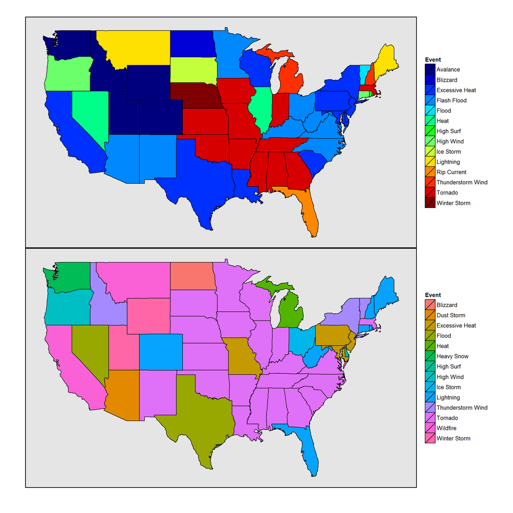

```r
################### preparation for the economic consequences results
## join the states data with the property data
statesproperty = merge(states_map, maxpropdamage, by.x = "region", by.y = "AreaName")
statesproperty$Event = as.factor(statesproperty$NWS)
p3 = ggplot()
p3 = p3 + theme(axis.ticks = element_blank(),
                axis.text.x = element_blank(), axis.text.y = element_blank(),
                axis.title.x = element_blank(), axis.title.y = element_blank(),
                panel.grid.minor=element_blank(), panel.grid.major=element_blank(),
                plot.margin = unit(c(1,1,0,1), "cm"),
                panel.margin = unit(c(1,1,0,1), "cm"),
                panel.border = element_rect(color = "black", fill=NA, size=1))
p3 = p3 + geom_polygon(data = statesproperty, aes(x=long, y=lat, group = group, fill = Event), color = "black")

## join the states data with the injury data
statescrops = merge(states_map, maxcropdamage, by.x = "region", by.y = "AreaName")
statescrops$Event = as.factor(statescrops$NWS)

p4 = ggplot()
p4 = p4 + theme(axis.ticks = element_blank(),
                axis.text.x = element_blank(), axis.text.y = element_blank(),
                axis.title.x = element_blank(), axis.title.y = element_blank(),
                panel.grid.minor=element_blank(), panel.grid.major=element_blank(),
                plot.margin = unit(c(-0.5,1,1,1), "cm"),
                panel.margin = unit(c(-0.5,1,1,1), "cm"),
                panel.border = element_rect(color = "black", fill=NA, size=1))
p4 = p4 + geom_polygon(data = statescrops, aes(x=long, y=lat, group = group, fill = Event), color = "black")
##p4 = p4 + scale_fill_manual(values = getPalette(length(unique(statescrops$Event))))
p4 = p4 + scale_fill_manual(values = palette)
##p4 = p4 + ggtitle("Event causing most crop damage per state")
```

**Figure 3. Weather-related events with the greatest economic consequences in each state. The top panel indicates the weather event leading to the greatest property damage in each state, while the bottom panel indicates the weather event leading to the greatest crop damage.**

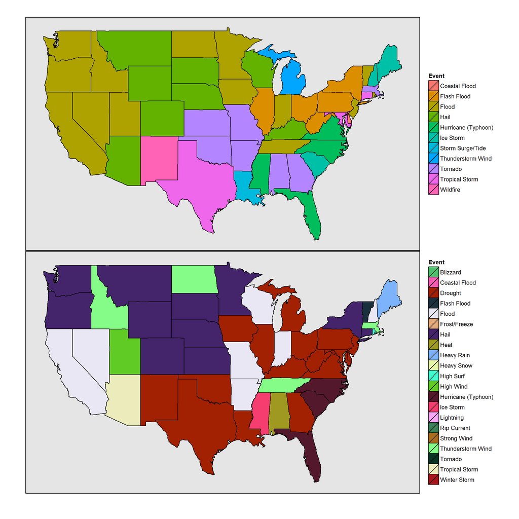

As can be seen in Figures 2 and 3, states vary widely in the type of weather events leading to population health and economic consequences.

## Summary

National weather service data between 1994 and 2011 were analyzed to determine the events most harmful across the US in terms of population health and economic consequences. State-level information was determined and shows a wide range of events harmful to population health and economic consequences. These results may be of use to government or municipal managers who might be responsible for planning and preparing for severe weather events.